The following example illustrates a simple use of the maxent model for relative species occurence prediction. The data set used for this example has been taken from the [GBIF database]http://www.gbif.org/ and encompasses four animal species which occure in Hessen, Germany. The study area is Hessen. Environmental data used in this study is taken from the [Copernicus site]http://land.copernicus.eu/pan-european and encompasses Corine land-cover class, forest types and tree crown densities. All raster datasets have been resampled to 100 m.

## Background sample as regular grid

Sample background information as a regular spaced grid from 10,000 locations. Split the background information dataset into four folds and compile four cross-validation samples with 3/4 training and 1/4 testing data.

```r
hessen <- readRDS(paste0(path_rdata, "v_hessen.rds"))
br <- sp::spsample(hessen, n = 10000, type = "regular")
br <- sp::SpatialPointsDataFrame(br, data.frame(NAME = rep("background", length(br))))
brfolds <- dismo::kfold(br, k=4)
br_train_test <- lapply(seq(4), function(i){
  test <- br[which(brfolds == i), ]
  train <- br[which(brfolds != i), ]
  list(training = train, test = test)
})

saveRDS(br, paste0(path_rdata, "v_br.rds"))
saveRDS(br_train_test, paste0(path_rdata, "br_train_test.rds"))
```

## Species sample random

```r
soc <- readRDS(paste0(path_rdata, "v_soc.rds"))
species <- unique(soc@data$NAME)

sr_train_test <- lapply(species, function(s){
  cur_soc <- soc[soc@data$NAME == s, ]
  cur_soc_folds <- dismo::kfold(cur_soc, k=4)
  sr_train_test <- lapply(seq(4), function(i){
    test <- cur_soc[which(cur_soc_folds == i), ]
    train <- cur_soc[which(cur_soc_folds != i), ]
    list(training = train, test = test)
  })
})
names(sr_train_test) <- species
saveRDS(sr_train_test, paste0(path_rdata, "sr_train_test.rds"))
```

## Compile species random/background random grid dataset

```r
br_train_test <- readRDS(paste0(path_rdata, "br_train_test.rds"))
sr_train_test <- readRDS(paste0(path_rdata, "sr_train_test.rds"))
species <- names(sr_train_test)

sr_br <- lapply(seq(length(sr_train_test)), function(s){
  cur_spec <- names(sr_train_test[s])
  cur_stt <- sr_train_test[[s]]
  train_test <- lapply(seq(length(cur_stt)), function(cs){

    train_occ <- cur_stt[[cs]]$training
    train_bgr <- br_train_test[[cs]]$training
    train_bgr@data$NAME <- paste(train_bgr@data$NAME, cur_spec, " ")

    test_occ <- cur_stt[[cs]]$test
    test_bgr <- br_train_test[[cs]]$test
    test_bgr@data$NAME <- paste(test_bgr@data$NAME, cur_spec, " ")

    training <- list(occurence = train_occ, background = train_bgr)
    test <- list(occurence = test_occ, background = test_bgr)
    return(list(training = training, test = test))
  })
  names(train_test) <- paste0("fold", seq(length(cur_stt)))
  return(train_test)
})
names(sr_br) <- species


saveRDS(sr_br, paste0(path_rdata, "sr_br.rds"))
```

## MaxENT species random/background random grid dataset (sr_br)

```r
hessen <- readRDS(paste0(path_rdata, "v_hessen.rds"))
sr_br <- readRDS(paste0(path_rdata, "sr_br.rds"))
env <- readRDS(paste0(path_rdata, "s_env.rds"))
mi_env <- env[[1:5]]

# Select only first species and first fold
s = 1
sf = 1
cur_sr_br <- sr_br[[s]]
cur_sr_br_sf <- cur_sr_br[[sf]]
```

```r
# Compute maxent model
me <- dismo::maxent(mi_env, p = cur_sr_br_sf$training$occurence, a = cur_sr_br_sf$training$background,
                    factors = c("g100_clc12_V18_5", "FAD_eur_020m_fin", "FTY_eur_020m_fin"),
                    path = paste0(path_model, "me_sr_br_s01_f01"))

# me # This would open the results in a browser
saveRDS(me, paste0(path_rdata, "me_eo-es-02-01.rds"))
```

Plot the variable importance of the maxent model

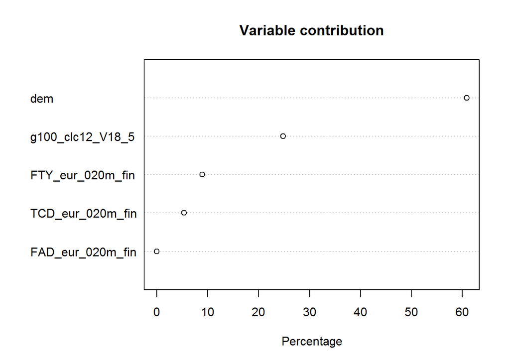

```r
# plot showing importance of each variable
plot(me)
```

Plot how the species distribution is explained by pairs of environmental data.

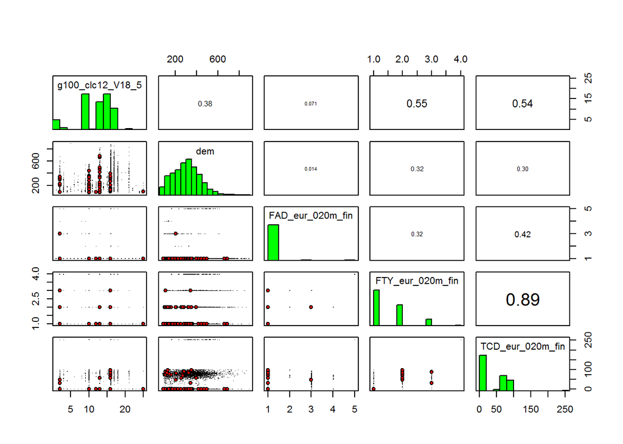

```r
pairs(me, pa = "pa")
```

Plot how the species distribution is explained individual environmental datasets.

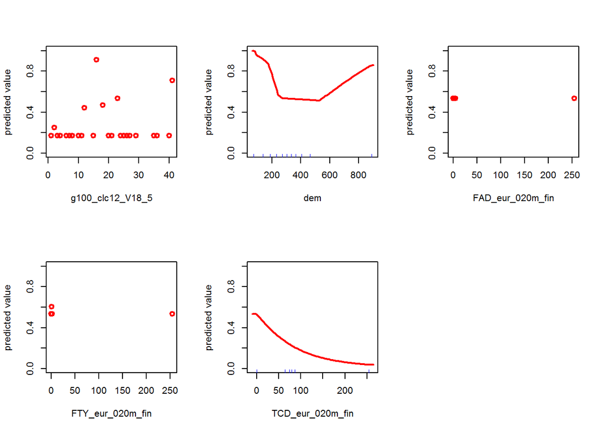

```r
response(me)
```

Evaluate the model using the hold-back test data of the first cross-validation fold.

```r
e_test <- dismo::evaluate(p=cur_sr_br_sf$test$occurence, a=cur_sr_br_sf$test$background, model = me, x = mi_env)
threshold(e_test)
```

```
##                kappa spec_sens no_omission prevalence equal_sens_spec
## thresholds 0.9240605 0.5489463  0.03269401 0.01190144       0.4686152
##            sensitivity
## thresholds   0.2556354
```

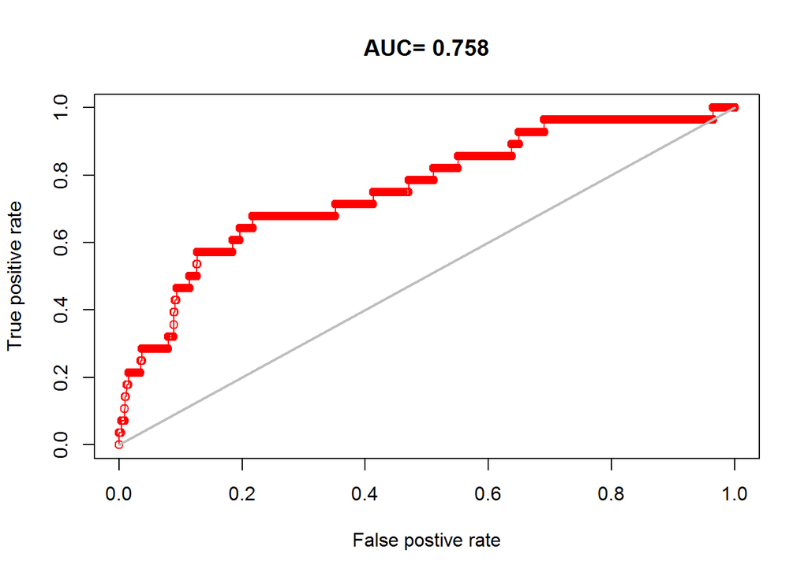

```r
plot(e_test, 'ROC')
```

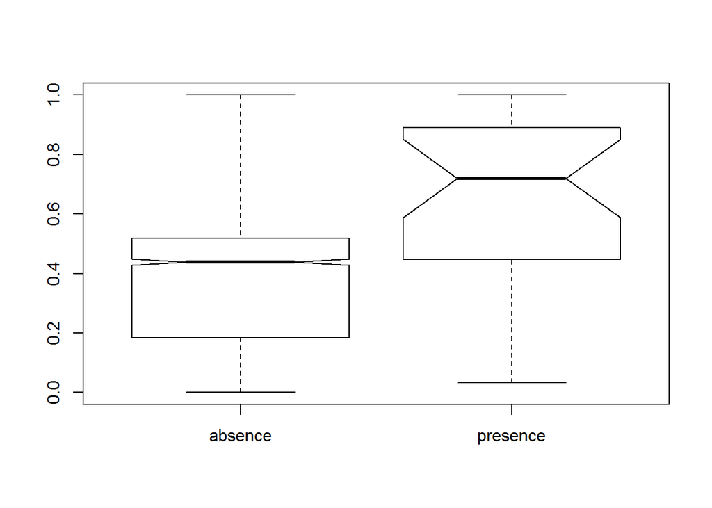

```r
boxplot(e_test)
```

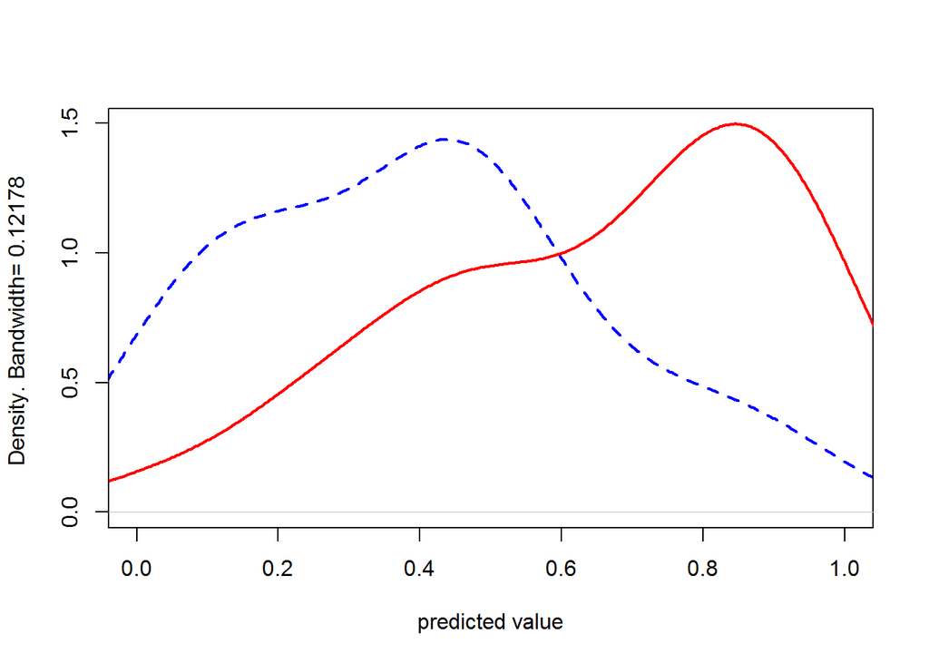

```r
density(e_test)
```

Show some statistic meassures of model performance

```r
threshold(e_test)
```

```
##                kappa spec_sens no_omission prevalence equal_sens_spec
## thresholds 0.9240605 0.5489463  0.03269401 0.01190144       0.4686152
##            sensitivity
## thresholds   0.2556354
```

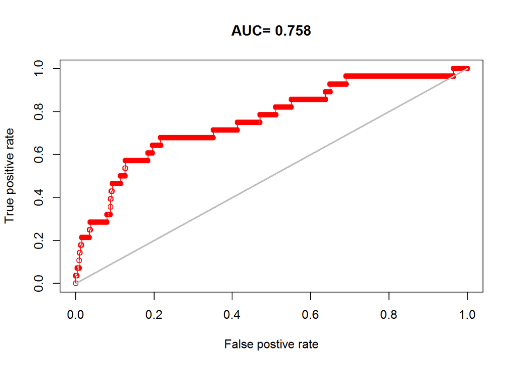

```r
plot(e_test, 'ROC')
```

Show how well occurence and background predictions separate.

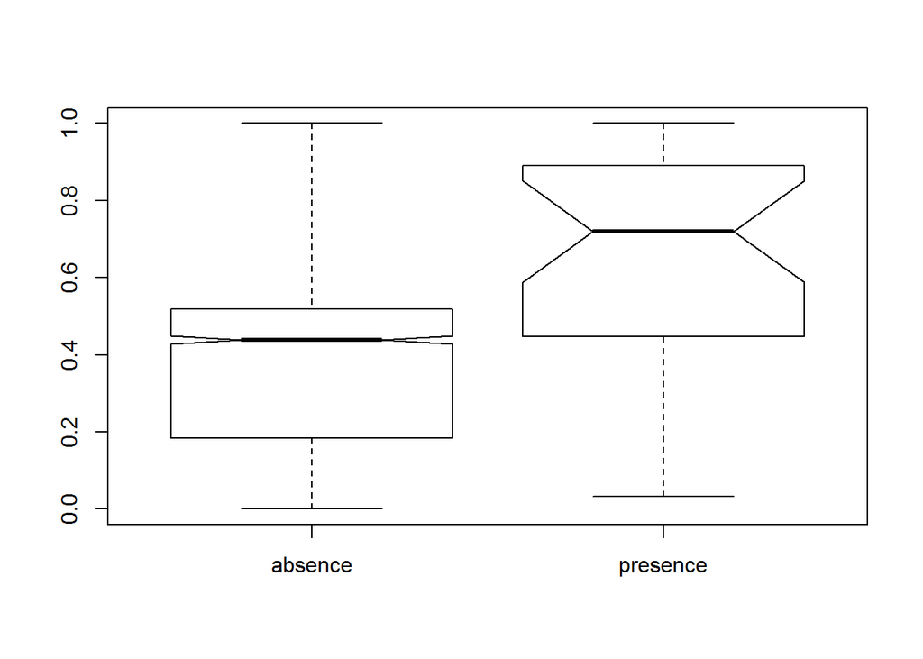

```r
boxplot(e_test)
```

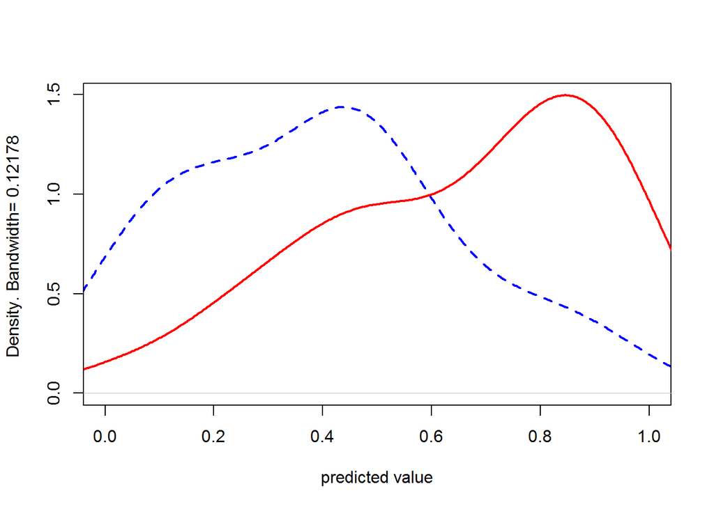

```r
density(e_test)
```